# HW4

Elif Konyar

4/29/2020

# Homework 4

```r
library(data.table)
library(stats)
library(monmlp)
library(BBmisc)
```

## Question 1

In this question, we are asked to implement multilayer perceptron algorithm to XOR problem which is two class classification problem. Since it is two class classification, the activation function will be sigmoid for all the layers and all the nodes.

Here, the sigmoid function and its derivative is defined:

```r
sigmoid <- function(x) {
  1 / ( 1 + exp((-1)*x) )
}

derivative = deriv(~ 1 / ( 1 + exp(-x) ), "x",func=T)
```

Data is given below:

```r
x1=c(0,0,1,1)
x2=c(0,1,0,1)
y=c(0,1,1,0)
input_q1=as.data.table(cbind(x1,x2,y))
```

Since there are several parameters to be decided such as learning parameter, number of iterations, number of nodes in the hidden layer, I did a parameter search to find the parameter set that truly classifies the input data. So, for learning rate, I tried 0.2, 0.25, … ,0.6; for the number of nodes in the hidden layer 2,3,…,12; the number of iterations 500,1000,…,2000.

```r
parameter_array=seq(0.2,0.6, by=0.05)
number_of_nodes_in_the_hidden_layer=seq(2,12,by=1) #2,12
max_iteration_number=c(500,1000,2000)
```

These are the selected parameters:

```r
#parameters
number_of_layers=3
number_of_neurons=c(2,2,1)
learning_rate=0.2
#bias=0
max_iterations=1000
cost_summary=data.table()
input=input_q1
```

The algorithm is given below:

Weights are initialized randomly from uniform distribution between -1 and 1.

Update rule:

Change_in_weight_ij<sup>k</sup>=learning_rate*delta_j<sup>(k+1)</sup>*o_i<sup>k</sup>

delta_j<sup>(k+1)</sup>=sum_over_l(delta_l<sup>(k+2)</sup>*weight_jl<sup>(k+1)</sup>)*f’(s_j<sup>(k+1)</sup>): for any hidden layer (k+1)

delta_j<sup>(k+1)</sup>=(t_j-o_j<sup>(k+1)</sup>)*f’(s_j<sup>(k+1)</sup>): for the output layer (k+1)

s_j<sup>(k+1)</sup>=sum_over_i(w_ij<sup>k</sup>*o_i<sup>k</sup>)

o_j<sup>(k+1)</sup>=f(s_j<sup>(k+1)</sup>)

Other necessary information is in the comments.

```r
MultilayerPerceptron_Classification= function(input,number_of_layers,number_of_neurons,learning_rate,bias,max_iterations){
  ###PART 1
  number_of_patterns=nrow(input) #4 in the first question
  class_column=ncol(input) #3 in the first question
  total_number_of_neurons=sum(number_of_neurons)

  set.seed(550)
  number_of_weights=0
  total_number_of_weights_in_the_previous_layers=matrix(0,nrow=number_of_layers,ncol=1)
  total_number_of_weights_in_the_previous_layers[1]=0
  for (i in 1:(length(number_of_neurons)-1)){
    number_of_weights=number_of_weights+prod(number_of_neurons[i:(i+1)])
    total_number_of_weights_in_the_previous_layers[i+1]=number_of_weights
  }
  #weight initialization
  weights=as.matrix(runif(number_of_weights,-1,1))

  #these are for index control in the loop
  #neuron_start_index_o_array: it keeps the starting node index from the previous layer
  neuron_start_index_o=0
  neuron_start_index_o_array=matrix(0,nrow=number_of_layers,ncol=1)
  neuron_start_index_o_array[1]=0
  neuron_start_index_o_array[2]=1
  for (i in 3:number_of_layers){
    neuron_start_index_o=neuron_start_index_o_array[i-1]+number_of_neurons[i-2]
    neuron_start_index_o_array[i]=neuron_start_index_o
  }

  #O, S and delta initialization
  o=matrix(0,nrow=total_number_of_neurons,ncol=1)
  s=matrix(0,nrow=total_number_of_neurons,ncol=1)
  delta=matrix(0,nrow=total_number_of_neurons,ncol=1)
  cost_summary=data.table()

  for (i in 1:max_iterations){
    #I feed the data one by one, controlling it in the n index.
    for (n in 1:number_of_patterns){
      #O and S initialization for each pattern and epoch
      o=matrix(0,nrow=total_number_of_neurons,ncol=1)
      s=matrix(0,nrow=total_number_of_neurons,ncol=1)
      #o_j_kplus1 calculation
      #for each layer, controlling it with the k index
      for (k in 1:number_of_layers){
        #for each node in this layer, controlling it with the t index
        for (t in 1:number_of_neurons[k]){
          #for the first layer, s is directly from the input data, o value is the output of the sigmoid function
          if (k==1){
            s[t,1]=as.numeric(input[n,t:t])
            o[t,1]=sigmoid(s[t,1])
            #for the other layers, s is calculated cumulatively with the o values from the previous layer multiplied with weights
          }else{
            #these are for index control in s update loop
            neuron_start_index=sum(number_of_neurons[1:(k-1)])+1 #the first node index in this layer
            neuron_end_index=neuron_start_index+number_of_neurons[k]-1
            number_of_neurons_in_the_previous_layer=number_of_neurons[k-1]
            number_of_neurons_in_this_layer=number_of_neurons[k]
            #neuron_start_index_o:the start index from the previous layer so that the summation can be done
            neuron_start_index_o=neuron_start_index_o_array[k]
            #update s
            for (w in 1:number_of_neurons_in_the_previous_layer){
              s[neuron_start_index+t-1,1]=s[neuron_start_index+t-1,1]+weights[total_number_of_weights_in_the_previous_layers[k-1]+(w-1)*number_of_neurons_in_this_layer+t]*o[neuron_start_index_o+w-1,1]
            }
            #after calculating s, o is calculated with the sigmoid function
            o[neuron_start_index+t-1,1]=sigmoid(s[neuron_start_index+t-1,1])
          }
        }
      }

      #keeping the weights from the previous iteration
      weights_previous=weights
      #BACKPROPAGATION
      #initializing delta
      delta=matrix(0,nrow=total_number_of_neurons,ncol=1)
      #from the last layer to the first layer
      for (k in number_of_layers:1){
        #for each node in the layer
        for(t in 1:number_of_neurons[k]){
          #if we are in the last layer:
          if (k==number_of_layers){
            #the first index in this layer:
            neuron_start_index=sum(number_of_neurons[1:(k-1)])+1
            #f(s_j^(k+1)) calculation
            gradient_at_s=as.numeric(attr(derivative(s[neuron_start_index+t-1,1]),'gradient'))
            #UPDATE DELTA
            delta[neuron_start_index+t-1,1]=(as.numeric(input[n,class_column:class_column])-o[neuron_start_index+t-1,1])*gradient_at_s
          }else{ #if we are in any layer other than the last layer
            #index control part
            neuron_start_index=ifelse(k==1,1,sum(number_of_neurons[1:(k-1)])+1)
            neuron_start_index_next_layer=sum(number_of_neurons[1:k])+1
            number_of_neurons_in_the_next_layer=number_of_neurons[k+1]
            #gradient calculation
            gradient_at_s=as.numeric(attr(derivative(s[neuron_start_index+t-1,1]),'gradient'))
            #UPDATE DELTA (the summation is over the nodes in the next layer)
            for(w in 1:number_of_neurons_in_the_next_layer){
              delta[neuron_start_index+t-1,1]=delta[neuron_start_index+t-1,1]+delta[neuron_start_index_next_layer+w-1,1]*weights[total_number_of_weights_in_the_previous_layers[k]+(t-1)*number_of_neurons_in_the_next_layer+w]*gradient_at_s
            }
          }
        }
      }
      #UPDATE WEIGHTS
      #from the last layer to the first layer
      for (k in number_of_layers:1){
        #for each node in the layer
        for(t in 1:number_of_neurons[k]){ #weights coming to that node is updated:
          if (k==number_of_layers){
            #index control part
            number_of_neurons_in_the_previous_layer=number_of_neurons[k-1]
            weight_start_index=total_number_of_weights_in_the_previous_layers[k-1]+((t-1)*number_of_neurons_in_the_previous_layer)+1
            neuron_start_index_previous_layer=sum(number_of_neurons[1:(k-2)])+1
            #UPDATE WEIGHT
            for(w in 1:number_of_neurons_in_the_previous_layer){
              weights[weight_start_index+w-1]=weights_previous[weight_start_index+w-1]+learning_rate*delta[neuron_start_index+t-1,1]*o[neuron_start_index_previous_layer+w-1,1]
            }
            #for the other layers
          }else if (k<(number_of_layers-1)){
            #weights going from that node is updated. Thus, k<(number_of_layers-1) is checked:
            #index control part
            number_of_neurons_in_the_next_layer=number_of_neurons[k+1]
            weight_start_index=(t-1)*number_of_neurons_in_the_next_layer+1
            neuron_start_index_next_layer=sum(number_of_neurons[1:k])+1
            neuron_start_index=ifelse(k==1,1,sum(number_of_neurons[1:(k-1)])+1)
            #UPDATE WEIGHT
            for(w in 1:number_of_neurons_in_the_next_layer){
              weights[weight_start_index+w-1]=weights_previous[weight_start_index+w-1]+learning_rate*delta[neuron_start_index_next_layer+w-1]*o[neuron_start_index+t-1]
            }
          }
        }
      }
    }

    #ASSIGN CLASSES
    #initializing
    classes=matrix(0,nrow=number_of_patterns,ncol=1)
    o=matrix(0,nrow=total_number_of_neurons,ncol=1)
    s=matrix(0,nrow=total_number_of_neurons,ncol=1)

    #class assignment is done with the last weight set
    for (n in 1:number_of_patterns){
      #for each pattern
      #o and s initialization for each pattern:
      o=matrix(0,nrow=total_number_of_neurons,ncol=1)
      s=matrix(0,nrow=total_number_of_neurons,ncol=1)
      for (k in 1:number_of_layers){
        #for each node in the layer (this part is similar to above o calculation)
        for (t in 1:number_of_neurons[k]){
          if (k==1){
            s[t,1]=as.numeric(input[n,t:t])
            o[t,1]=sigmoid(s[t,1])
          }else{
            neuron_start_index=sum(number_of_neurons[1:(k-1)])+1
            neuron_end_index=neuron_start_index+number_of_neurons[k]-1
            number_of_neurons_in_the_previous_layer=number_of_neurons[k-1]
            number_of_neurons_in_this_layer=number_of_neurons[k]
            neuron_start_index_o=neuron_start_index_o_array[k]
            for (w in 1:number_of_neurons_in_the_previous_layer){
              s[neuron_start_index+t-1,1]=s[neuron_start_index+t-1,1]+weights[total_number_of_weights_in_the_previous_layers[k-1]+(w-1)*number_of_neurons_in_this_layer+t]*o[neuron_start_index_o+w-1,1]
            }
            o[neuron_start_index+t-1,1]=sigmoid(s[neuron_start_index+t-1,1])
          }
        }
      }
      #CLASS ASSIGNMENT
      #if (o_j^(k+1)<0.5 assign 0 else assign 1)
      classes[n,1]=ifelse(o[total_number_of_neurons,1]<0.5,0,1)
    }

    #COST CALCULATION:
    #cost=1/2*(sum_over_j((t_j-y_j)^2))
    cost_iter=0
    for (n in 1:number_of_patterns){
      cost_iter=cost_iter+(as.numeric(input[n,class_column:class_column])-as.numeric(classes[n,1]))^2
    }
    cost_summary<-rbind(cost_summary,data.table(Iteration=i,Cost=cost_iter))
  }
  cost_summary <<- cost_summary

  fwrite(as.data.table(cost_summary),"/Users/elifkonyar/Desktop/EE 550/HW1/cost_summary.csv")
  return(weights)


}
```

Class assignment part is given below in case any test set is used. We can control it from the input parameter of the function:

Necessary information is in the comments:

```r
CalculateClasses_Classification= function(input,weights,number_of_layers,number_of_neurons){
  #This part until the loop is the same with the above function.
  number_of_patterns=nrow(input)
  class_column=ncol(input)
  total_number_of_neurons=sum(number_of_neurons)

  number_of_weights=0
  total_number_of_weights_in_the_previous_layers=matrix(0,nrow=number_of_layers,ncol=1)
  total_number_of_weights_in_the_previous_layers[1]=0
  for (i in 1:(length(number_of_neurons)-1)){
    number_of_weights=number_of_weights+prod(number_of_neurons[i:(i+1)])
    total_number_of_weights_in_the_previous_layers[i+1]=number_of_weights
  }

  neuron_start_index_o=0
  neuron_start_index_o_array=matrix(0,nrow=number_of_layers,ncol=1)
  neuron_start_index_o_array[1]=0
  neuron_start_index_o_array[2]=1
  for (i in 3:number_of_layers){
    neuron_start_index_o=neuron_start_index_o_array[i-1]+number_of_neurons[i-2]
    neuron_start_index_o_array[i]=neuron_start_index_o
  }

  classes=matrix(0,nrow=number_of_patterns,ncol=1)
  o=matrix(0,nrow=total_number_of_neurons,ncol=1)
  s=matrix(0,nrow=total_number_of_neurons,ncol=1)

  #CLASS ASSIGNMENT
  #This is the same with the class assignment part from the above function and it is explained above.
  for (n in 1:number_of_patterns){
    o=matrix(0,nrow=total_number_of_neurons,ncol=1)
    s=matrix(0,nrow=total_number_of_neurons,ncol=1)
    for (k in 1:number_of_layers){
      for (t in 1:number_of_neurons[k]){
        if (k==1){
          s[t,1]=as.numeric(input[n,t:t])
          o[t,1]=sigmoid(s[t,1])
        }else{
          neuron_start_index=sum(number_of_neurons[1:(k-1)])+1
          neuron_end_index=neuron_start_index+number_of_neurons[k]-1
          number_of_neurons_in_the_previous_layer=number_of_neurons[k-1]
          number_of_neurons_in_this_layer=number_of_neurons[k]
          neuron_start_index_o=neuron_start_index_o_array[k]
          for (w in 1:number_of_neurons_in_the_previous_layer){
            s[neuron_start_index+t-1,1]=s[neuron_start_index+t-1,1]+weights[total_number_of_weights_in_the_previous_layers[k-1]+(w-1)*number_of_neurons_in_this_layer+t]*o[neuron_start_index_o+w-1,1]
          }
          #s[neuron_start_index+t-1,1]=s[neuron_start_index+t-1,1]+bias
          o[neuron_start_index+t-1,1]=sigmoid(s[neuron_start_index+t-1,1])
        }
      }
    }
    classes[n,1]=ifelse(o[total_number_of_neurons,1]<0.5,0,1)
  }
  return(classes)
}
```

As mentioned above, parameter search is done below:

```r
#i=1
summary=data.table()
for (param in parameter_array){
  for (node in number_of_nodes_in_the_hidden_layer){
    for (max_iter in max_iteration_number){
      number_of_neurons=c(2,node,1)
      learning_rate=param
      max_iterations=max_iter
      weights_q1=MultilayerPerceptron_Classification(input_q1,number_of_layers,number_of_neurons,learning_rate,bias,max_iterations)
      classes_q1=CalculateClasses_Classification(input_q1,weights_q1,number_of_layers,number_of_neurons)

      summary=rbind(summary,data.table(t(classes_q1),number_of_neuron=node,learning_rate=param,iter=max_iterations))
#      print(i)
#      print(param)
#      print(t(classes_q1))
#      i=i+1
    }
  }
}
head(summary,6)
```

```
##    V1 V2 V3 V4 number_of_neuron learning_rate iter
## 1:  1  1  1  1                2           0.2  500
## 2:  0  1  1  1                2           0.2 1000
## 3:  0  1  1  1                2           0.2 2000
## 4:  1  1  1  1                3           0.2  500
## 5:  1  1  1  1                3           0.2 1000
## 6:  1  1  1  1                3           0.2 2000
```

However, in none of the cases, the data is classified correctly. Thus, I chose one of the parameter sets with the highest accuracy.

```r
#parameters
number_of_layers=3
number_of_neurons=c(2,2,1)
learning_rate=0.2
#bias=0
max_iterations=1000
cost_summary=data.table()
input=input_q1
#weights are updated:
weights_q1=MultilayerPerceptron_Classification(input_q1,number_of_layers,number_of_neurons,learning_rate,bias,max_iterations)
#class assignment is done:
classes_q1=CalculateClasses_Classification(input_q1,weights_q1,number_of_layers,number_of_neurons)
```

Total cost function vs number of epochs:

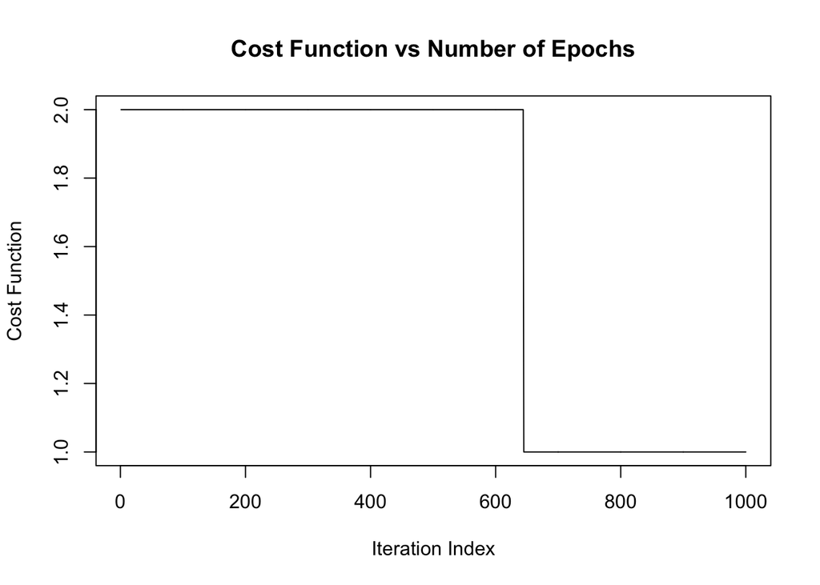

```r
cost_summary=fread("/Users/elifkonyar/Desktop/EE 550/HW1/cost_summary.csv")

plot(cost_summary$Iteration,cost_summary$Cost,type="l",
     main="Cost Function vs Number of Epochs",
     xlab="Iteration Index",
     ylab="Cost Function")
```

```r
#cost_summary$Cost
```

The outputs for each pattern in order:

```r
classes_q1
```

```
##      [,1]
## [1,]    0
## [2,]    1
## [3,]    1
## [4,]    1
```

I can’t get the correct desired outputs for the whole set. Although I checked the o, s, delta, weight updates and indices for several iterations and several sample patters, and they seem correct, I can’t get the desired output. I don’t know if you will check the code to see how the algorithm is implemented, but in case you just check the final output, I will put results for o, s, delta and weights for a small network with 3 layers and with 2,3,1 neurons. The results will be only for the first iteration and 2 sample patterns:

```r
number_of_layers=3
number_of_neurons=c(2,3,1)
learning_rate=0.2
```

1st iteration: after 1st sample pattern:

Initial weights:

```
##            V1
## 1:  0.4887906
## 2:  0.2483858
## 3:  0.9606105
## 4:  0.4977879
## 5:  0.8680272
## 6: -0.9503874
## 7:  0.6897844
## 8:  0.4308085
## 9: -0.2450171
```

S values:

```
##             V1
## 1: 0.000000000
## 2: 0.000000000
## 3: 0.493289204
## 4: 0.558206455
## 5: 0.005111583
## 6: 0.579462678
```

O values:

```
##           V1
## 1: 0.5000000
## 2: 0.5000000
## 3: 0.6208810
## 4: 0.6360374
## 5: 0.5012779
## 6: 0.6409438
```

delta values:

```
##              V1
## 1: -0.001670243
## 2: -0.008319457
## 3: -0.023949675
## 4: -0.014710450
## 5:  0.009035161
## 6: -0.147503500
```

weights:

```
##            V1
## 1:  0.4863956
## 2:  0.2469147
## 3:  0.9615140
## 4:  0.4953929
## 5:  0.8665561
## 6: -0.9494838
## 7:  0.6895770
## 8:  0.4305960
## 9: -0.2451846
```

1st iteration: after 2nd sample pattern:

S values:

```
##            V1
## 1:  0.0000000
## 2:  1.0000000
## 3:  0.6053590
## 4:  0.7569606
## 5: -0.2133713
## 6:  0.6296156
```

O values:

```
##           V1
## 1: 0.5000000
## 2: 0.7310586
## 3: 0.6468814
## 4: 0.6806935
## 5: 0.4468586
## 6: 0.6524023
```

Delta values:

```
##               V1
## 1:  0.0008168947
## 2:  0.0033580740
## 3:  0.0124164459
## 4:  0.0073773204
## 5: -0.0047771478
## 6:  0.0788259622
```

Weight values:

```
##            V1
## 1:  0.4876372
## 2:  0.2476524
## 3:  0.9610363
## 4:  0.4972083
## 5:  0.8676348
## 6: -0.9501823
## 7:  0.6896827
## 8:  0.4307072
## 9: -0.2451115
```

## QUESTION 2

In this question, now we have a nonlinear function sin(x). I generated 60 data points for training with uniform distribution between 0 and 2 and then multiplied them with pi. Also, I generated 25 data points for the test set.

```r
set.seed(550)
input_q2=runif(60,0,2)
input_q2=as.matrix(input_q2*pi)
input_q2=cbind(input_q2,apply(input_q2,2,sin))

test_q2=runif(25,0,2)
test_q2=as.matrix(test_q2*pi)
test_q2=cbind(test_q2,apply(test_q2,2,sin))
```

Since the data is one dimension, there is one node in the first layer and one node in the last layer. Instead of maximum number of iterations, cost threshold is used in this question. Threshold is chosen from the trials because I don’t know the range the cost can get in this specific question even with a nearly perferct model. So, the threshold is chosen as 21.5. The other parameters are given below:

```r
number_of_layers=5
number_of_neurons=c(1,10,7,6,1)
learning_rate=0.2
bias=0
#max_iterations=500
cost_threshold=21.5
cost_summary=data.table()
input=input_q2
```

In this question, I learnt that in regression problems, generally, the activation function of the output layer is pure linear function. Also, the activation function for the hidden layers is tangent sigmoid function. purelin() is defined below for the pure linear function. For the tangent sigmoid function tansig() function is used.

```r
purelin=function(x){
  x
}
```

The algorithm is given below. The same update rules are implemented. The only difference comes in the activation functions, the class assignment part in the end and the stopping condition. Since this is a regression problem, there is no class assignment, and the output is the input in the last layer with purelin() function.

```r
MultilayerPerceptron_Regression= function(input,number_of_layers,number_of_neurons,learning_rate,bias,max_iterations){
  number_of_patterns=nrow(input)
  class_column=ncol(input)
  total_number_of_neurons=sum(number_of_neurons)

  set.seed(550)
  number_of_weights=0
  total_number_of_weights_in_the_previous_layers=matrix(0,nrow=number_of_layers,ncol=1)
  total_number_of_weights_in_the_previous_layers[1]=0
  for (i in 1:(length(number_of_neurons)-1)){
    number_of_weights=number_of_weights+prod(number_of_neurons[i:(i+1)])
    total_number_of_weights_in_the_previous_layers[i+1]=number_of_weights
  }
  weights=as.matrix(runif(number_of_weights,-1,1))

  neuron_start_index_o=0
  neuron_start_index_o_array=matrix(0,nrow=number_of_layers,ncol=1)
  neuron_start_index_o_array[1]=0
  neuron_start_index_o_array[2]=1
  for (i in 3:number_of_layers){
    neuron_start_index_o=neuron_start_index_o_array[i-1]+number_of_neurons[i-2]
    neuron_start_index_o_array[i]=neuron_start_index_o
  }

  o=matrix(0,nrow=total_number_of_neurons,ncol=1)
  s=matrix(0,nrow=total_number_of_neurons,ncol=1)
  delta=matrix(0,nrow=total_number_of_neurons,ncol=1)
  #o_multip_w=matrix(0,nrow=total_number_of_neurons,ncol=1)
  #o_class_output_layer=matrix(0,nrow=number_of_neurons[number_of_layers],ncol=1)
  cost_summary=data.table()

  cost_iter=9999
  i=1
  while(cost_iter>cost_threshold){
    for (n in 1:number_of_patterns){
      o=matrix(0,nrow=total_number_of_neurons,ncol=1)
      s=matrix(0,nrow=total_number_of_neurons,ncol=1)
      #o_multip_w=matrix(0,nrow=total_number_of_neurons,ncol=1)
      #o_j_kplus1 calculation
      for (k in 1:number_of_layers){
        for (t in 1:number_of_neurons[k]){
          if (k==1){
            s[t,1]=as.numeric(input[n,t:t])
            o[t,1]=tansig(s[t,1])
            #o_multip_w[t,1]=o[t,1]*weights[t,1]
          }else{
            neuron_start_index=sum(number_of_neurons[1:(k-1)])+1
            neuron_end_index=neuron_start_index+number_of_neurons[k]-1
            number_of_neurons_in_the_previous_layer=number_of_neurons[k-1]
            number_of_neurons_in_this_layer=number_of_neurons[k]
            neuron_start_index_o=neuron_start_index_o_array[k]
            for (w in 1:number_of_neurons_in_the_previous_layer){
              s[neuron_start_index+t-1,1]=s[neuron_start_index+t-1,1]+weights[total_number_of_weights_in_the_previous_layers[k-1]+(w-1)*number_of_neurons_in_this_layer+t]*o[neuron_start_index_o+w-1,1]
            }
            #s[neuron_start_index+t-1,1]=s[neuron_start_index+t-1,1]+bias
            o[neuron_start_index+t-1,1]=ifelse(k==number_of_layers, purelin(s[neuron_start_index+t-1,1]),tansig(s[neuron_start_index+t-1,1]))
            #o_class_output_layer[t]=ifelse(o[neuron_start_index+t-1,1]<0.5,0,1)
          }
        }
      }

      weights_previous=weights
      #backpropagation
      delta=matrix(0,nrow=total_number_of_neurons,ncol=1)
      for (k in number_of_layers:1){
        for(t in 1:number_of_neurons[k]){
          if (k==number_of_layers){
            neuron_start_index=sum(number_of_neurons[1:(k-1)])+1
            gradient_at_s=as.numeric(attr(derivative(s[neuron_start_index+t-1,1]),'gradient'))
            delta[neuron_start_index+t-1,1]=(as.numeric(input[n,class_column:class_column])-o[neuron_start_index+t-1,1])*gradient_at_s
          }else{
            #neuron_start_index=ifelse(k==2,sum(number_of_neurons[1:(k-1)])+1,1)
            neuron_start_index=ifelse(k==1,1,sum(number_of_neurons[1:(k-1)])+1)
            neuron_start_index_next_layer=sum(number_of_neurons[1:k])+1
            number_of_neurons_in_the_next_layer=number_of_neurons[k+1]
            gradient_at_s=as.numeric(attr(derivative(s[neuron_start_index+t-1,1]),'gradient'))
            for(w in 1:number_of_neurons_in_the_next_layer){
              delta[neuron_start_index+t-1,1]=delta[neuron_start_index+t-1,1]+delta[neuron_start_index_next_layer+w-1,1]*weights[total_number_of_weights_in_the_previous_layers[k]+(t-1)*number_of_neurons_in_the_next_layer+w]*gradient_at_s
            }
          }
        }
      }
      #update weights
      for (k in number_of_layers:1){
        for(t in 1:number_of_neurons[k]){
          if (k==number_of_layers){
            #update weights
            number_of_neurons_in_the_previous_layer=number_of_neurons[k-1]
            weight_start_index=total_number_of_weights_in_the_previous_layers[k-1]+((t-1)*number_of_neurons_in_the_previous_layer)+1
            neuron_start_index_previous_layer=sum(number_of_neurons[1:(k-2)])+1
            for(w in 1:number_of_neurons_in_the_previous_layer){
              weights[weight_start_index+w-1]=weights_previous[weight_start_index+w-1]+learning_rate*delta[neuron_start_index+t-1,1]*o[neuron_start_index_previous_layer+w-1,1]
            }
          }else if (k<(number_of_layers-1)){
            number_of_neurons_in_the_next_layer=number_of_neurons[k+1]
            weight_start_index=(t-1)*number_of_neurons_in_the_next_layer+1
            neuron_start_index_next_layer=sum(number_of_neurons[1:k])+1
            neuron_start_index=ifelse(k==1,1,sum(number_of_neurons[1:(k-1)])+1)
            for(w in 1:number_of_neurons_in_the_next_layer){
              weights[weight_start_index+w-1]=weights_previous[weight_start_index+w-1]+learning_rate*delta[neuron_start_index_next_layer+w-1]*o[neuron_start_index+t-1]
            }
          }
        }
      }
    }

    #calculate classes
    classes=matrix(0,nrow=number_of_patterns,ncol=1)
    o=matrix(0,nrow=total_number_of_neurons,ncol=1)
    s=matrix(0,nrow=total_number_of_neurons,ncol=1)

    for (n in 1:number_of_patterns){
      o=matrix(0,nrow=total_number_of_neurons,ncol=1)
      s=matrix(0,nrow=total_number_of_neurons,ncol=1)
      for (k in 1:number_of_layers){
        for (t in 1:number_of_neurons[k]){
          if (k==1){
            s[t,1]=as.numeric(input[n,t:t])
            o[t,1]=tansig(s[t,1])
            #o_multip_w[t,1]=o[t,1]*weights[t,1]
          }else{
            neuron_start_index=sum(number_of_neurons[1:(k-1)])+1
            neuron_end_index=neuron_start_index+number_of_neurons[k]-1
            number_of_neurons_in_the_previous_layer=number_of_neurons[k-1]
            number_of_neurons_in_this_layer=number_of_neurons[k]
            neuron_start_index_o=neuron_start_index_o_array[k]
            for (w in 1:number_of_neurons_in_the_previous_layer){
              s[neuron_start_index+t-1,1]=s[neuron_start_index+t-1,1]+weights[total_number_of_weights_in_the_previous_layers[k-1]+(w-1)*number_of_neurons_in_this_layer+t]*o[neuron_start_index_o+w-1,1]
            }
            o[neuron_start_index+t-1,1]=ifelse(k==number_of_layers, purelin(s[neuron_start_index+t-1,1]),tansig(s[neuron_start_index+t-1,1]))
          }
        }
      }
      classes[n,1]=o[total_number_of_neurons,1]
    }

    cost_iter=0
    for (n in 1:number_of_patterns){
      cost_iter=cost_iter+(as.numeric(input[n,class_column:class_column])-as.numeric(classes[n,1]))^2
    }
    cost_summary<-rbind(cost_summary,data.table(Iteration=i,Cost=cost_iter))
    i=i+1
  }
  cost_summary <<- cost_summary
  fwrite(as.data.table(cost_summary),"/Users/elifkonyar/Desktop/EE 550/HW1/cost_summary_q2.csv")

  return(weights)


}
```

The outputs with the last weights are calculated below. It is similar to CalculateClasses_Classification() function from the question 1. The only difference is there is no class assignment. Also, the activation functions are different.

```r
CalculateOutput_Regression= function(input,weights,number_of_layers,number_of_neurons){
  number_of_patterns=nrow(input)
  class_column=ncol(input)
  total_number_of_neurons=sum(number_of_neurons)

  number_of_weights=0
  total_number_of_weights_in_the_previous_layers=matrix(0,nrow=number_of_layers,ncol=1)
  total_number_of_weights_in_the_previous_layers[1]=0
  for (i in 1:(length(number_of_neurons)-1)){
    number_of_weights=number_of_weights+prod(number_of_neurons[i:(i+1)])
    total_number_of_weights_in_the_previous_layers[i+1]=number_of_weights
  }

  neuron_start_index_o=0
  neuron_start_index_o_array=matrix(0,nrow=number_of_layers,ncol=1)
  neuron_start_index_o_array[1]=0
  neuron_start_index_o_array[2]=1
  for (i in 3:number_of_layers){
    neuron_start_index_o=neuron_start_index_o_array[i-1]+number_of_neurons[i-2]
    neuron_start_index_o_array[i]=neuron_start_index_o
  }

  output=matrix(0,nrow=number_of_patterns,ncol=1)
  o=matrix(0,nrow=total_number_of_neurons,ncol=1)
  s=matrix(0,nrow=total_number_of_neurons,ncol=1)

  for (n in 1:number_of_patterns){
    o=matrix(0,nrow=total_number_of_neurons,ncol=1)
    s=matrix(0,nrow=total_number_of_neurons,ncol=1)
    for (k in 1:number_of_layers){
      for (t in 1:number_of_neurons[k]){
        if (k==1){
          s[t,1]=as.numeric(input[n,t:t])
          o[t,1]=tansig(s[t,1])
          #o_multip_w[t,1]=o[t,1]*weights[t,1]
        }else{
          neuron_start_index=sum(number_of_neurons[1:(k-1)])+1
          neuron_end_index=neuron_start_index+number_of_neurons[k]-1
          number_of_neurons_in_the_previous_layer=number_of_neurons[k-1]
          number_of_neurons_in_this_layer=number_of_neurons[k]
          neuron_start_index_o=neuron_start_index_o_array[k]
          for (w in 1:number_of_neurons_in_the_previous_layer){
            s[neuron_start_index+t-1,1]=s[neuron_start_index+t-1,1]+weights[total_number_of_weights_in_the_previous_layers[k-1]+(w-1)*number_of_neurons_in_this_layer+t]*o[neuron_start_index_o+w-1,1]
          }
          #s[neuron_start_index+t-1,1]=s[neuron_start_index+t-1,1]+bias
          o[neuron_start_index+t-1,1]=ifelse(k==number_of_layers, purelin(s[neuron_start_index+t-1,1]),tansig(s[neuron_start_index+t-1,1]))
        }
      }
    }
    output[n,1]=o[total_number_of_neurons,1]
  }
  return(output)
}
```

Weights and the outputs are calculated below:

```r
#weights are updated
weights_q2=MultilayerPerceptron_Regression(input_q2,number_of_layers,number_of_neurons,learning_rate,bias,max_iterations)
#outputs are calculated for the training set
output_q2=CalculateOutput_Regression(input_q2,weights_q2,number_of_layers,number_of_neurons)
#View(cost_summary)
#THE OUTPUTS FOR THE TEST SET: It is calculated with the same weights. Only the given data is different. It is "test_q2"
test_output_q2=CalculateOutput_Regression(test_q2,weights_q2,number_of_layers,number_of_neurons)
```

Total cost function for the training set vs number of epochs:

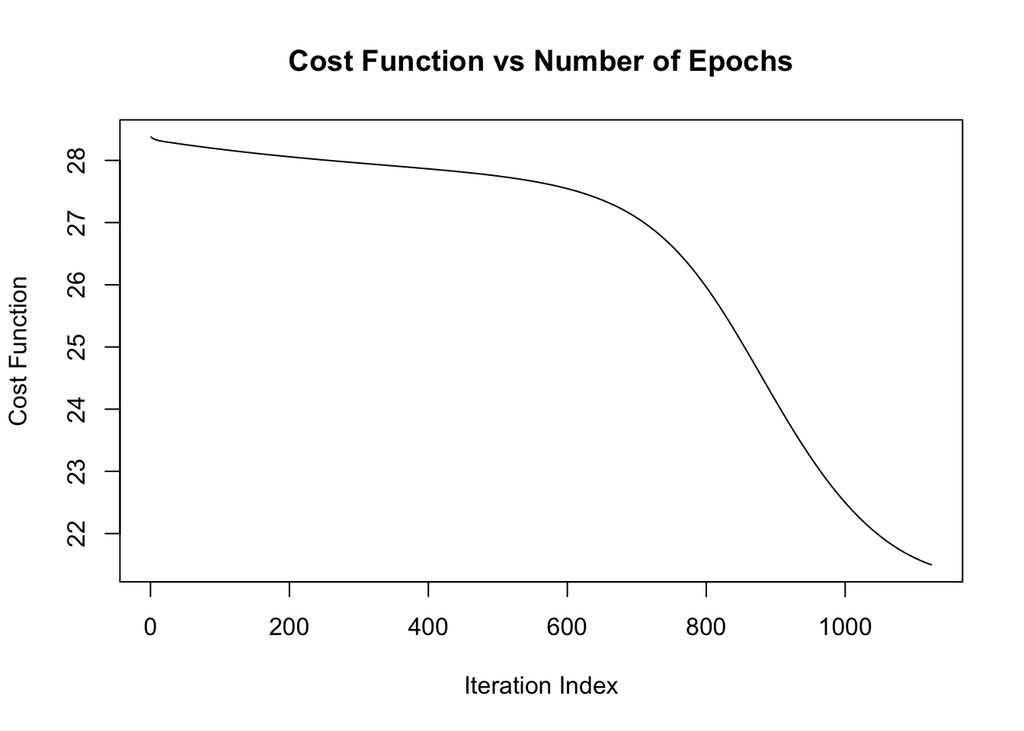

```r
cost_summary=fread("/Users/elifkonyar/Desktop/EE 550/HW1/cost_summary_q2.csv")
plot(cost_summary$Iteration,cost_summary$Cost,type="l",
     main="Cost Function vs Number of Epochs",
     xlab="Iteration Index",
     ylab="Cost Function")
```

The plot of the approximate graph with 25 test values is below:

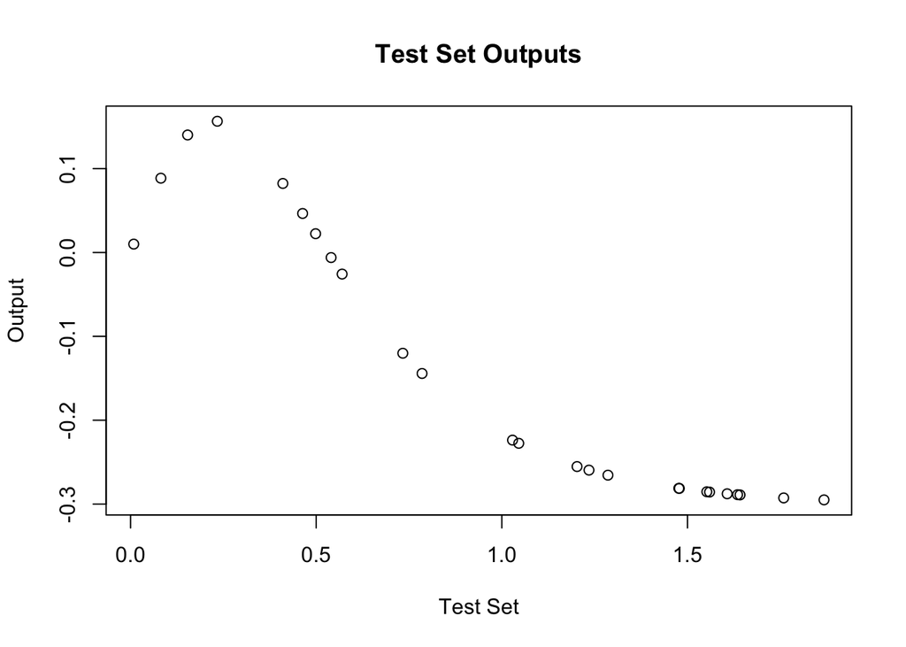

```r
plot(test_q2[,1:1]/pi,test_output_q2,
     main="Test Set Outputs",
     xlab="Test Set",
     ylab="Output")
```

## Question 3

In this question, we are asked to use Handwritten Digits dataset. The output in this data set is multi-class, so it is a multi-class classification problem. There are 10 classes in this data set. The training and the test splitting part is below. For each class, 40 observations are taken for the training set and 10 for the test set. The class information is in the 65th column.

```r
data_q3=as.data.table(read.table("/Users/elifkonyar/Desktop/EE 550/HW1/optdigits.tes",sep=",")) #v65 class
#40 train 10 test
number_of_class=10
number_of_train=40
number_of_test=10
train_q3=data.table()
test_q3=data.table()
for (i in 0:(number_of_class-1)){
  data_class=data_q3[V65==i]
  train_class=data_class[1:number_of_train,]
  test_class=data_class[(number_of_train+1):(number_of_train+number_of_test),]

  train_q3=rbind(train_q3,train_class)
  test_q3=rbind(test_q3,test_class)
}

train_q3=as.matrix(train_q3)
test_q3=as.matrix(test_q3)
```

```r
#parameters
number_of_layers=6
number_of_neurons=c(64,8,10,5,5,10)
learning_rate=0.3
bias=0
max_iterations=100
cost_summary=data.table()
```

The training data is shuffled before the algorithm because all the classes are ordered now. Thus, when the data feeding starts, it will start with all the class 0 observations.

```r
#shuffling the data
rows <- sample(nrow(train_q3))
train_q3 <- train_q3[rows, ]
input=train_q3
```

The algorithm is given below. The same update rules are implemented. The only difference comes in the activation functions, the class assignment part in the end and the stopping condition. In the hidden layers, the activation function is sigmoid as in the 2-class classification problem. However, in the output layer, the activation function is softmax. The softmax output is calculated by first taking the exponential of the inputs to the nodes in the output layer, and then dividing them to the sum of the exponential values in that layer. The higher softmax output means belonging to that class with higher probability. Hence, the class assigment is done according to the highest softmax outputs. The other parts is similar with the other questions.

```r
MultilayerPerceptron_MultiClassClassification= function(input,number_of_layers,number_of_neurons,learning_rate,bias,max_iterations){
  number_of_patterns=nrow(input)
  class_column=ncol(input)
  total_number_of_neurons=sum(number_of_neurons)

  set.seed(550)
  number_of_weights=0
  total_number_of_weights_in_the_previous_layers=matrix(0,nrow=number_of_layers,ncol=1)
  total_number_of_weights_in_the_previous_layers[1]=0
  for (i in 1:(length(number_of_neurons)-1)){
    number_of_weights=number_of_weights+prod(number_of_neurons[i:(i+1)])
    total_number_of_weights_in_the_previous_layers[i+1]=number_of_weights
  }
  weights=as.matrix(runif(number_of_weights,-1,1))

  neuron_start_index_o=0
  neuron_start_index_o_array=matrix(0,nrow=number_of_layers,ncol=1)
  neuron_start_index_o_array[1]=0
  neuron_start_index_o_array[2]=1
  for (i in 3:number_of_layers){
    neuron_start_index_o=neuron_start_index_o_array[i-1]+number_of_neurons[i-2]
    neuron_start_index_o_array[i]=neuron_start_index_o
  }

  o=matrix(0,nrow=total_number_of_neurons,ncol=1)
  s=matrix(0,nrow=total_number_of_neurons,ncol=1)
  delta=matrix(0,nrow=total_number_of_neurons,ncol=1)
  #o_multip_w=matrix(0,nrow=total_number_of_neurons,ncol=1)
  #o_class_output_layer=matrix(0,nrow=number_of_neurons[number_of_layers],ncol=1)
  cost_summary=data.table()

  for (i in 1:max_iterations){
    for (n in 1:number_of_patterns){
      o=matrix(0,nrow=total_number_of_neurons,ncol=1)
      s=matrix(0,nrow=total_number_of_neurons,ncol=1)
      #o_multip_w=matrix(0,nrow=total_number_of_neurons,ncol=1)
      #o_j_kplus1 calculation
      for (k in 1:number_of_layers){
        for (t in 1:number_of_neurons[k]){
          if (k==1){
            s[t,1]=as.numeric(input[n,t:t])
            o[t,1]=sigmoid(s[t,1])
            #o_multip_w[t,1]=o[t,1]*weights[t,1]
          }else{
            neuron_start_index=sum(number_of_neurons[1:(k-1)])+1
            neuron_end_index=neuron_start_index+number_of_neurons[k]-1
            number_of_neurons_in_the_previous_layer=number_of_neurons[k-1]
            number_of_neurons_in_this_layer=number_of_neurons[k]
            neuron_start_index_o=neuron_start_index_o_array[k]
            for (w in 1:number_of_neurons_in_the_previous_layer){
              s[neuron_start_index+t-1,1]=s[neuron_start_index+t-1,1]+weights[total_number_of_weights_in_the_previous_layers[k-1]+(w-1)*number_of_neurons_in_this_layer+t]*o[neuron_start_index_o+w-1,1]
            }
            #s[neuron_start_index+t-1,1]=s[neuron_start_index+t-1,1]+bias
            o[neuron_start_index+t-1,1]=sigmoid(s[neuron_start_index+t-1,1])
            #o_class_output_layer[t]=ifelse(o[neuron_start_index+t-1,1]<0.5,0,1)
          }
        }
        #SOFTMAX PART
        if (k==number_of_layers){
          expon=matrix(0,nrow=number_of_neurons[k],ncol=1)
          neuron_start_index=sum(number_of_neurons[1:(k-1)])+1
          neuron_end_index=neuron_start_index+number_of_neurons[k]-1
          #exp(z)/sum(exp(z))
          for (t in 1:number_of_neurons[k]){
            expon[t]=exp(s[neuron_start_index+t-1,1])
          }
          sum_expon=sum(expon)
          expon=expon/sum_expon
          for (t in 1:number_of_neurons[k]){
            o[neuron_start_index+t-1,1]=expon[t]
          }
        }
      }

      weights_previous=weights
      #BACKPROPAGATION
      delta=matrix(0,nrow=total_number_of_neurons,ncol=1)
      for (k in number_of_layers:1){
        for(t in 1:number_of_neurons[k]){
          if (k==number_of_layers){
            neuron_start_index=sum(number_of_neurons[1:(k-1)])+1
            gradient_at_s=as.numeric(attr(derivative(s[neuron_start_index+t-1,1]),'gradient'))
            delta[neuron_start_index+t-1,1]=(as.numeric(input[n,class_column:class_column])-o[neuron_start_index+t-1,1])*gradient_at_s
          }else{
            #neuron_start_index=ifelse(k==2,sum(number_of_neurons[1:(k-1)])+1,1)
            neuron_start_index=ifelse(k==1,1,sum(number_of_neurons[1:(k-1)])+1)
            neuron_start_index_next_layer=sum(number_of_neurons[1:k])+1
            number_of_neurons_in_the_next_layer=number_of_neurons[k+1]
            gradient_at_s=as.numeric(attr(derivative(s[neuron_start_index+t-1,1]),'gradient'))
            for(w in 1:number_of_neurons_in_the_next_layer){
              delta[neuron_start_index+t-1,1]=delta[neuron_start_index+t-1,1]+delta[neuron_start_index_next_layer+w-1,1]*weights[total_number_of_weights_in_the_previous_layers[k]+(t-1)*number_of_neurons_in_the_next_layer+w]*gradient_at_s
            }
          }
        }
      }
      #update weights
      for (k in number_of_layers:1){
        for(t in 1:number_of_neurons[k]){
          if (k==number_of_layers){
            #update weights
            number_of_neurons_in_the_previous_layer=number_of_neurons[k-1]
            weight_start_index=total_number_of_weights_in_the_previous_layers[k-1]+((t-1)*number_of_neurons_in_the_previous_layer)+1
            neuron_start_index_previous_layer=sum(number_of_neurons[1:(k-2)])+1
            for(w in 1:number_of_neurons_in_the_previous_layer){
              weights[weight_start_index+w-1]=weights_previous[weight_start_index+w-1]+learning_rate*delta[neuron_start_index+t-1,1]*o[neuron_start_index_previous_layer+w-1,1]
            }
          }else if (k<(number_of_layers-1)){
            number_of_neurons_in_the_next_layer=number_of_neurons[k+1]
            weight_start_index=(t-1)*number_of_neurons_in_the_next_layer+1
            neuron_start_index_next_layer=sum(number_of_neurons[1:k])+1
            neuron_start_index=ifelse(k==1,1,sum(number_of_neurons[1:(k-1)])+1)
            for(w in 1:number_of_neurons_in_the_next_layer){
              weights[weight_start_index+w-1]=weights_previous[weight_start_index+w-1]+learning_rate*delta[neuron_start_index_next_layer+w-1]*o[neuron_start_index+t-1]
            }
          }
        }
      }
    }

    #CALCULATE CLASSES
    classes=matrix(0,nrow=number_of_patterns,ncol=1)
    o=matrix(0,nrow=total_number_of_neurons,ncol=1)
    s=matrix(0,nrow=total_number_of_neurons,ncol=1)

    for (n in 1:number_of_patterns){
      o=matrix(0,nrow=total_number_of_neurons,ncol=1)
      s=matrix(0,nrow=total_number_of_neurons,ncol=1)
      for (k in 1:number_of_layers){
        for (t in 1:number_of_neurons[k]){
          if (k==1){
            s[t,1]=as.numeric(input[n,t:t])
            o[t,1]=sigmoid(s[t,1])
            #o_multip_w[t,1]=o[t,1]*weights[t,1]
          }else{
            neuron_start_index=sum(number_of_neurons[1:(k-1)])+1
            neuron_end_index=neuron_start_index+number_of_neurons[k]-1
            number_of_neurons_in_the_previous_layer=number_of_neurons[k-1]
            number_of_neurons_in_this_layer=number_of_neurons[k]
            neuron_start_index_o=neuron_start_index_o_array[k]
            for (w in 1:number_of_neurons_in_the_previous_layer){
              s[neuron_start_index+t-1,1]=s[neuron_start_index+t-1,1]+weights[total_number_of_weights_in_the_previous_layers[k-1]+(w-1)*number_of_neurons_in_this_layer+t]*o[neuron_start_index_o+w-1,1]
            }
            #s[neuron_start_index+t-1,1]=s[neuron_start_index+t-1,1]+bias
            o[neuron_start_index+t-1,1]=sigmoid(s[neuron_start_index+t-1,1])
          }
        }
        if (k==number_of_layers){
          expon=matrix(0,nrow=number_of_neurons[k],ncol=1)
          neuron_start_index=sum(number_of_neurons[1:(k-1)])+1
          neuron_end_index=neuron_start_index+number_of_neurons[k]-1
          #exp(z)/sum(exp(z))
          for (t in 1:number_of_neurons[k]){
            expon[t]=exp(s[neuron_start_index+t-1,1])
          }
          sum_expon=sum(expon)
          expon=expon/sum_expon
          for (t in 1:number_of_neurons[k]){
            o[neuron_start_index+t-1,1]=expon[t]
          }
          pattern_class=which(expon==max(expon))-1
        }
      }
      classes[n,1]=pattern_class
    }

    cost_iter=0
    for (n in 1:number_of_patterns){
      cost_iter=cost_iter+(as.numeric(input[n,class_column:class_column])-as.numeric(classes[n,1]))^2
    }
    cost_summary<-rbind(cost_summary,data.table(Iteration=i,Cost=cost_iter))
  }
  cost_summary <<- cost_summary
  #fwrite(as.data.table(cost_summary),"/Users/elifkonyar/Desktop/EE 550/HW1/cost_summary_q3.csv")
  return(weights)
}
```

The class assignment with the last weights are calculated below. It is similar to CalculateClasses_Classification() or CalculateClasses_Regression() function from the previous questions. The only difference is there are 10 classes now. Also, the activation functions are different.

```r
CalculateClasses_MultiClassClassification= function(input,weights,number_of_layers,number_of_neurons){
  number_of_patterns=nrow(input)
  class_column=ncol(input)
  total_number_of_neurons=sum(number_of_neurons)

  number_of_weights=0
  total_number_of_weights_in_the_previous_layers=matrix(0,nrow=number_of_layers,ncol=1)
  total_number_of_weights_in_the_previous_layers[1]=0
  for (i in 1:(length(number_of_neurons)-1)){
    number_of_weights=number_of_weights+prod(number_of_neurons[i:(i+1)])
    total_number_of_weights_in_the_previous_layers[i+1]=number_of_weights
  }

  neuron_start_index_o=0
  neuron_start_index_o_array=matrix(0,nrow=number_of_layers,ncol=1)
  neuron_start_index_o_array[1]=0
  neuron_start_index_o_array[2]=1
  for (i in 3:number_of_layers){
    neuron_start_index_o=neuron_start_index_o_array[i-1]+number_of_neurons[i-2]
    neuron_start_index_o_array[i]=neuron_start_index_o
  }

  classes=matrix(0,nrow=number_of_patterns,ncol=1)
  o=matrix(0,nrow=total_number_of_neurons,ncol=1)
  s=matrix(0,nrow=total_number_of_neurons,ncol=1)

  for (n in 1:number_of_patterns){
    o=matrix(0,nrow=total_number_of_neurons,ncol=1)
    s=matrix(0,nrow=total_number_of_neurons,ncol=1)
    for (k in 1:number_of_layers){
      for (t in 1:number_of_neurons[k]){
        if (k==1){
          s[t,1]=as.numeric(input[n,t:t])
          o[t,1]=sigmoid(s[t,1])
          #o_multip_w[t,1]=o[t,1]*weights[t,1]
        }else{
          neuron_start_index=sum(number_of_neurons[1:(k-1)])+1
          neuron_end_index=neuron_start_index+number_of_neurons[k]-1
          number_of_neurons_in_the_previous_layer=number_of_neurons[k-1]
          number_of_neurons_in_this_layer=number_of_neurons[k]
          neuron_start_index_o=neuron_start_index_o_array[k]
          for (w in 1:number_of_neurons_in_the_previous_layer){
            s[neuron_start_index+t-1,1]=s[neuron_start_index+t-1,1]+weights[total_number_of_weights_in_the_previous_layers[k-1]+(w-1)*number_of_neurons_in_this_layer+t]*o[neuron_start_index_o+w-1,1]
          }
          #s[neuron_start_index+t-1,1]=s[neuron_start_index+t-1,1]+bias
          o[neuron_start_index+t-1,1]=sigmoid(s[neuron_start_index+t-1,1])
        }
      }
      if (k==number_of_layers){
        expon=matrix(0,nrow=number_of_neurons[k],ncol=1)
        neuron_start_index=sum(number_of_neurons[1:(k-1)])+1
        neuron_end_index=neuron_start_index+number_of_neurons[k]-1
        #exp(z)/sum(exp(z))
        for (t in 1:number_of_neurons[k]){
          expon[t]=exp(s[neuron_start_index+t-1,1])
        }
        sum_expon=sum(expon)
        expon=expon/sum_expon
        for (t in 1:number_of_neurons[k]){
          o[neuron_start_index+t-1,1]=expon[t]
        }
        pattern_class=which(expon==max(expon))-1
      }
    }
    classes[n,1]=pattern_class
  }
  return(classes)
}
```

```r
weights_q3=MultilayerPerceptron_MultiClassClassification(train_q3,number_of_layers,number_of_neurons,learning_rate,bias,max_iterations)
output_q3=CalculateClasses_MultiClassClassification(train_q3,weights_q3,number_of_layers,number_of_neurons)
output_test_q3=CalculateClasses_MultiClassClassification(test_q3,weights_q3,number_of_layers,number_of_neurons)
```

Total cost function for the training set vs number of epochs:

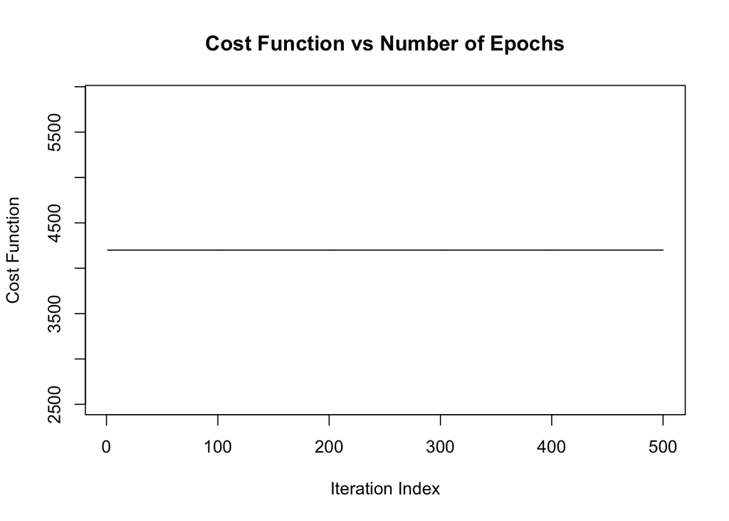

```r
cost_summary=fread("/Users/elifkonyar/Desktop/EE 550/HW1/cost_summary_q3.csv")
plot(cost_summary$Iteration,cost_summary$Cost,type="l",
     main="Cost Function vs Number of Epochs",
     xlab="Iteration Index",
     ylab="Cost Function")
```

Since there are 100 sample patterns for the test set, I will plot only 5 of them chosen randomly.

```r
rows <- sample(nrow(test_q3))
rows=rows[1:5]
test_plot <- test_q3[rows, ]
test_output_subset=output_test_q3[rows,]
```

First one:

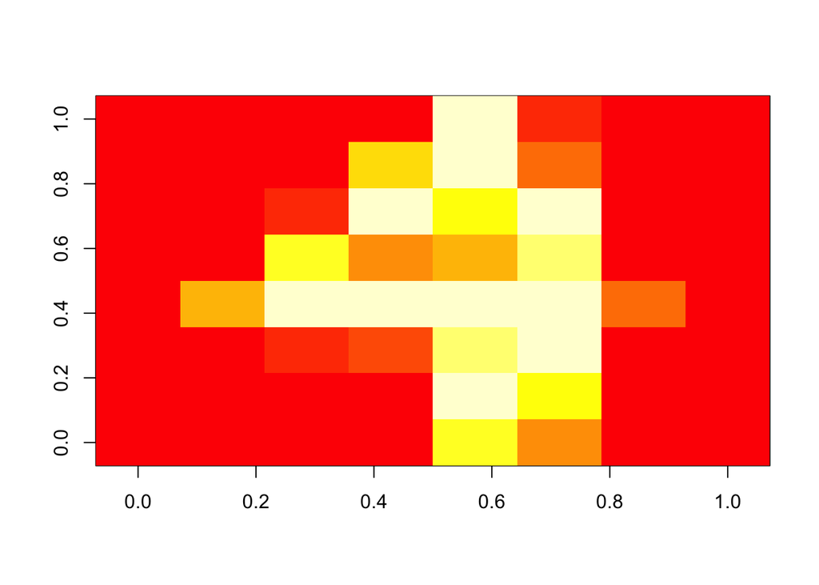

```r
rotate <- function(x) t(apply(x, 2, rev))
mat=matrix(test_plot[1:1,1:64],nrow=8,ncol = 8,byrow = T)
image(rotate(mat))
```

The desired output is:

```r
test_plot[1:1,65:65]
```

```
## V65
##   4
```

The predicted output is:

```r
test_output_subset[1:1]
```

```
## [1] 3
```

Second one:

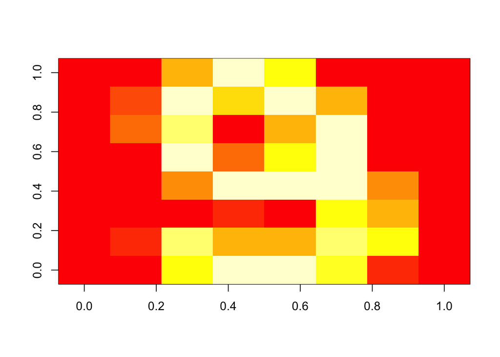

```r
mat=matrix(test_plot[2:2,1:64],nrow=8,ncol = 8,byrow = T)
image(rotate(mat))
```

The desired output is:

```r
test_plot[2:2,65:65]
```

```
## V65
##   9
```

The predicted output is:

```r
test_output_subset[2:2]
```

```
## [1] 3
```

Third one:

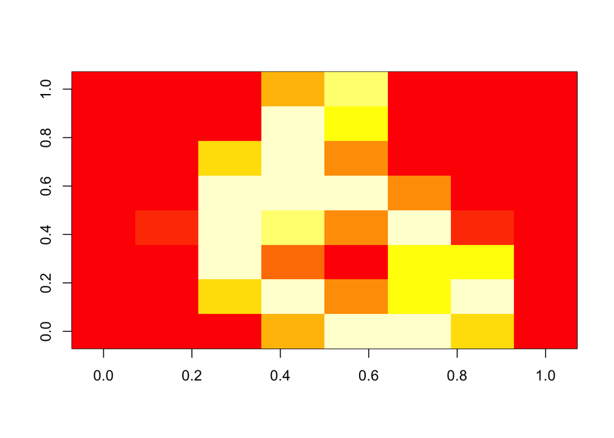

```r
mat=matrix(test_plot[3:3,1:64],nrow=8,ncol = 8,byrow = T)
image(rotate(mat))
```

The desired output is:

```r
test_plot[3:3,65:65]
```

```
## V65
##   6
```

The predicted output is:

```r
test_output_subset[3:3]
```

```
## [1] 3
```

Fourth one:

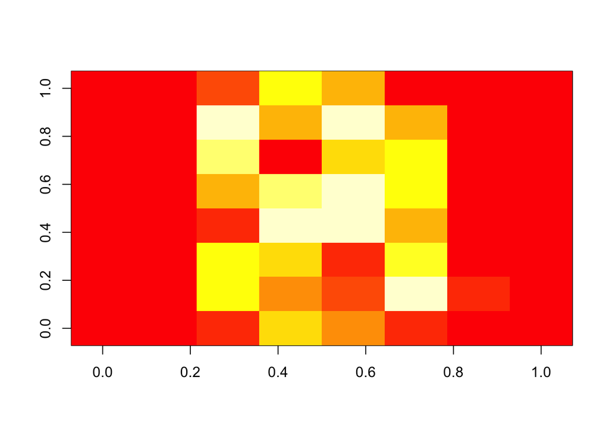

```r
mat=matrix(test_plot[4:4,1:64],nrow=8,ncol = 8,byrow = T)
image(rotate(mat))
```

The desired output is:

```r
test_plot[4:4,65:65]
```

```
## V65
##   8
```

The predicted output is:

```r
test_output_subset[4:4]
```

```
## [1] 3
```

Fifth one:

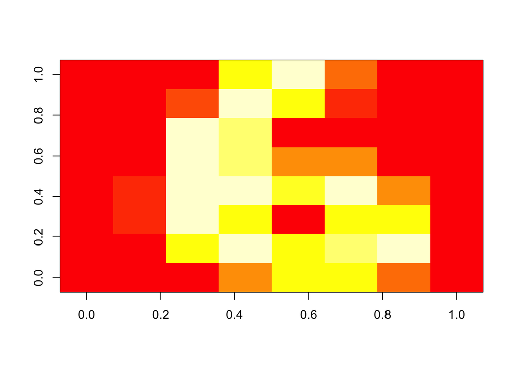

```r
mat=matrix(test_plot[5:5,1:64],nrow=8,ncol = 8,byrow = T)
image(rotate(mat))
```

The desired output is:

```r
test_plot[5:5,65:65]
```

```
## V65
##   6
```

The predicted output is:

```r
test_output_subset[5:5]
```

```
## [1] 3
```